# Stock Market EDA Project Documentation

St.John

2024-04-08

## Introduction

#### **Business Task**

Identify trends and patterns in historical stock market data to optimize investment strategies and enhance portfolio performance for Investors.

#### **Purpose**

The purpose of this business task is to leverage historical stock market data to gain insights into trends, patterns and relationships. By doing so, we aim to optimize investment strategies and enhance portfolio performance for stakeholders who are interested in investing in the technology service sector and financial service sector.

#### **Approach**

To accomplish this task, an Exploratory Data Analysis (EDA) on historical stock market data for the top 4 stocks in both the technology and financial service sectors was conducted. which involved gathering, preprocessing, analyzing, and visualizing the data to identify key trends, correlations, and patterns.

#### **Guiding Questions**

Some of the questions in which the project aimed to answer included;

1. How is the historical stock market data structured? What are the main variables and features?
2. Are there any missing values or outliers that need to be addressed?
3. What are the distributions of stock prices, trading volumes, and other relevant metrics?
4. Are there any notable relationships, in the data that warrant further investigation?
5. Are there any seasonal patterns or cyclical trends in each sector’s stock market performance?
6. How do different sectors, or individual stocks behave over time?

#### **Expected Outcome**

Through this analysis, I anticipate uncovering valuable insights into the behavior of stock prices, volumes, market returns, and volatility over time. These insights will inform the development of more effective investment strategies tailored to the specific characteristics of the technology and finance sectors.

## Data Prepration

#### **Getting the Data from the Quantmod Yahoo Finance API**

The foundation of my exploratory data analysis is based on historical stock data from leading companies within the technology service and financial service sectors. To acquire this data, I used the `quantmod` package in R, which is designed for quantitative financial modelling and trading strategy development. My first step involved selecting the stock symbols for the top 4 companies in each sector, chosen for their market capitalization and relevance to my study. This included **AAPL**, **MSFT**, **META**, and **GOOG** for technology services and **JPM**, **BAC**, **WFC**, and **HSBC** for financial services.

#### **Packages Used in this stage**

- `library(quantmod)`: This package facilitates access to financial data sources and provides various functions for financial modelling and data analysis.

#### **Code Implementation**

```r
# Getting the Data from the Quantmod Yahoo Finance API
# Define the stock symbols of the top 4 technology service and banking and financial services companies
symbols <- c("AAPL", "JPM", "MSFT", "BAC", "META", "WFC", "GOOG", "HSBC")

# Set the start and end dates
start_date <- as.Date("2019-01-01")
end_date <- as.Date("2023-12-31")

# Fetch the stock data from the API
getSymbols(symbols, src = "yahoo", from = start_date, to = end_date)
```

```
## [1] "AAPL" "JPM"  "MSFT" "BAC"  "META" "WFC"  "GOOG" "HSBC"
```

#### **Description**

I utilized Quantmod’s get Symbols function to query the Yahoo Finance API, retrieving historical data for the selected stock symbols covering the period from January 1, 2019, to December 31, 2023. This dataset includes daily open, high, low, and close prices (OHLC), along with trading volumes, providing a comprehensive foundation for the analysis that follows.

#### **Outcome**

The successful acquisition of this data marks the completion of the initial stage of my project. With this rich historical dataset, I am now prepared to dive deeper into analyzing stock market trends, comparing sector performances, and identifying potential areas of investment opportunity.

## Data PreProcessing

The objective of this stage is to preprocess the gathered historical stock data to ensure consistency, accuracy, and suitability for analysis. This includes handling data type formats, renaming columns, dealing with missing values, adding additional columns, detecting outliers, and performing feature engineering.

#### **Packages Used in this stage**

- `library(skimr)` used for checking missing values
- `library(lubridate)` used for date feature engineering
- `library(dplyr)` used for data manipulation and cleaning
- `library(ggplot2)` used for visualization
- `library(outliers)` used to detect outilers
- `library(tidyr)` used for data manipulation

#### **Description of tasks in this stage**

#### **Preparing the Data Frames**

The initial step in preparing the data for analysis involved passing the fetched stock data into separate data frames for each stock using the `as.data.frame()` function. This crucial step facilitated ease of manipulation and analysis in subsequent stages.

```r
# Passing the fetched data into the dataframe for ease of manipulation
apple_stockdata <- as.data.frame(AAPL)
jpmorgan_stockdata <- as.data.frame(JPM)
microsoft_stockdata <- as.data.frame(MSFT)
bankofAmerica_stockdata <- as.data.frame(BAC)
meta_stockdata <- as.data.frame(META)
wellsfargo_stockdata <- as.data.frame(WFC)
google_stockdata <- as.data.frame(GOOG)
hsbc_stockdata <- as.data.frame(HSBC)
```

#### **Data Type Adjustments and Renaming Columns**

To ensure accuracy in the data’s format, the first variable, originally stored as a row, was transformed into a column, thereby correctly positioning the date information. This adjustment was pivotal for time-series analysis and was accomplished using the `data.frame()` function. Consistency across data frames was achieved by standardizing column names, utilizing the `rename()` function from the dplyr package. This step was essential for maintaining clarity and uniformity across datasets.

```r
# Handle inaccurate data type format
# Make the first variable which is stored as a row to be a column and assign it the date as column name
apple_stockdata <- data.frame(date = rownames(apple_stockdata),
                               apple_stockdata, row.names = NULL)
jpmorgan_stockdata <- data.frame(date = rownames(jpmorgan_stockdata),
                                jpmorgan_stockdata, row.names = NULL)
microsoft_stockdata <- data.frame(date = rownames(microsoft_stockdata),
                                   microsoft_stockdata, row.names = NULL)
bankofAmerica_stockdata <- data.frame(date = rownames(bankofAmerica_stockdata),
                                bankofAmerica_stockdata, row.names = NULL)
meta_stockdata <- data.frame(date = rownames(meta_stockdata),
                                      meta_stockdata, row.names = NULL)
wellsfargo_stockdata <- data.frame(date = rownames(wellsfargo_stockdata),
                             wellsfargo_stockdata, row.names = NULL)
google_stockdata <- data.frame(date = rownames(google_stockdata),
                                   google_stockdata, row.names = NULL)
hsbc_stockdata <- data.frame(date = rownames(hsbc_stockdata),
                               hsbc_stockdata, row.names = NULL)
```

```r
# Renaming column names for consistency
apple_stockdata <- apple_stockdata %>% rename(
  Date = date,
  Open = AAPL.Open,
  High = AAPL.High,
  Low  = AAPL.Low,
  Close = AAPL.Close,
  Volume = AAPL.Volume,
  Adju_Close = AAPL.Adjusted
)

jpmorgan_stockdata <- jpmorgan_stockdata %>% rename(
  Date = date,
  Open = JPM.Open,
  High = JPM.High,
  Low  = JPM.Low,
  Close = JPM.Close,
  Volume = JPM.Volume,
  Adju_Close = JPM.Adjusted
)

microsoft_stockdata <- microsoft_stockdata %>% rename(
  Date = date,
  Open = MSFT.Open,
  High = MSFT.High,
  Low  = MSFT.Low,
  Close = MSFT.Close,
  Volume = MSFT.Volume,
  Adju_Close = MSFT.Adjusted
)

bankofAmerica_stockdata <- bankofAmerica_stockdata %>% rename(
  Date = date,
  Open = BAC.Open,
  High = BAC.High,
  Low  = BAC.Low,
  Close = BAC.Close,
  Volume = BAC.Volume,
  Adju_Close = BAC.Adjusted
)

meta_stockdata <- meta_stockdata %>% rename(
  Date = date,
  Open = META.Open,
  High = META.High,
  Low  = META.Low,
  Close = META.Close,
  Volume = META.Volume,
  Adju_Close = META.Adjusted
)

wellsfargo_stockdata <- wellsfargo_stockdata %>% rename(
  Date = date,
  Open = WFC.Open,
  High = WFC.High,
  Low  = WFC.Low,
  Close = WFC.Close,
  Volume = WFC.Volume,
  Adju_Close = WFC.Adjusted
)

google_stockdata <- google_stockdata %>% rename(
  Date = date,
  Open = GOOG.Open,
  High = GOOG.High,
  Low  = GOOG.Low,
  Close = GOOG.Close,
  Volume = GOOG.Volume,
  Adju_Close = GOOG.Adjusted
)

hsbc_stockdata <- hsbc_stockdata %>% rename(
  Date = date,
  Open = HSBC.Open,
  High = HSBC.High,
  Low  = HSBC.Low,
  Close = HSBC.Close,
  Volume = HSBC.Volume,
  Adju_Close = HSBC.Adjusted
)
```

#### **Missing Values Check**

A thorough inspection for missing values in each stock dataset was conducted using the `skim_without_charts()` function from the skimr package. This preemptive check ensured that the analysis was based on complete data, mitigating potential biases or inaccuracies.

```r
#Did Same for other stocks with all having same results for missing values
# Results showing no missing values in the dataset
skim_without_charts(apple_stockdata)
```

Data summary

| Name | apple_stockdata |
| --- | --- |
| Number of rows | 1258 |
| Number of columns | 7 |
| _______________________ |  |
| Column type frequency: |  |
| character | 1 |
| numeric | 6 |
| ________________________ |  |
| Group variables | None |

**Variable type: character**

| skim_variable | n_missing | complete_rate | min | max | empty | n_unique | whitespace |
| --- | --- | --- | --- | --- | --- | --- | --- |
| Date | 0 | 1 | 10 | 10 | 0 | 1258 | 0 |

**Variable type: numeric**

| skim_variable | n_missing | complete_rate | mean | sd | p0 | p25 | p50 | p75 | p100 |
| --- | --- | --- | --- | --- | --- | --- | --- | --- | --- |
| Open | 0 | 1 | 122.91 | 46.51 | 35.99 | 76.86 | 134.79 | 159.73 | 1.9802e+02 |
| High | 0 | 1 | 124.32 | 46.94 | 36.43 | 78.00 | 136.00 | 162.12 | 1.9962e+02 |
| Low | 0 | 1 | 121.60 | 46.09 | 35.50 | 76.11 | 133.33 | 157.71 | 1.9700e+02 |
| Close | 0 | 1 | 123.03 | 46.53 | 35.55 | 77.38 | 134.61 | 159.67 | 1.9811e+02 |
| Volume | 0 | 1 | 101590434.18 | 52610869.28 | 24048300.00 | 68030125.00 | 88617400.00 | 118978600.00 | 4.2651e+08 |
| Adju_Close | 0 | 1 | 121.25 | 46.70 | 34.03 | 75.19 | 132.31 | 157.80 | 1.9759e+02 |

#### **Symbol Identification and Dataframe Consolidation**

To distinguish between stocks, a stock symbol column was appended to each dataset. Subsequently, all individual stock data frames were combined into a unified dataframe named stock_market_data using the `rbind()` function, streamlining the dataset for comprehensive analysis.

```r
# Adding Stock symbol as a column name in each dataset before combining into a big dataset
apple_stockdata$Symbol <- "AAPL"
jpmorgan_stockdata$Symbol <- "JPM"
microsoft_stockdata$Symbol <- "MSFT"
bankofAmerica_stockdata$Symbol <- "BAC"
meta_stockdata$Symbol <- "META"
wellsfargo_stockdata$Symbol <- "WFC"
google_stockdata$Symbol <- "GOOG"
hsbc_stockdata$Symbol <- "HSBC"

# Combining all data into a single dataframe
stock_market_data <- apple_stockdata
stock_market_data <- rbind(stock_market_data, jpmorgan_stockdata)
stock_market_data <- rbind(stock_market_data, microsoft_stockdata)
stock_market_data <- rbind(stock_market_data, bankofAmerica_stockdata)
stock_market_data <- rbind(stock_market_data, meta_stockdata)
stock_market_data <- rbind(stock_market_data, wellsfargo_stockdata)
stock_market_data <- rbind(stock_market_data, google_stockdata)
stock_market_data <- rbind(stock_market_data, hsbc_stockdata)
```

#### **Sector and Company Classification**

The dataset was further enriched by adding Sector and Company columns. This classification was based on stock symbols and was achieved by merging the data with a lookup table, utilizing the `merge()` function. This addition allowed for more nuanced sector-specific analyses.

```r
# Add Sector and Company Column based on the Stock Symbols
sector_company_lookup <- data.frame(
  Symbol = c("AAPL", "JPM", "MSFT", "BAC", "META", "WFC", "GOOG", "HSBC"),
  Sector = c("Technology", "Financials", "Technology", "Financials", "Technology", "Financials", "Technology", "Financials"),
  Company = c("Apple Inc.", "JPMorgan Chase & Co.",
              "Microsoft Corporation", "Bank of America Corporation",
              "Meta Platforms, Inc.", "Wells Fargo" , "Google", "HSBC Holdings plc")
)

# Merge the lookup table with the stock_market_data based on the 'Symbol' column
stock_market_data <- merge(stock_market_data, sector_company_lookup, by = "Symbol", all.x = TRUE)

# Reorder the columns so that the Date colum is first
stock_market_data <-stock_market_data[, c("Date", "Open", "High", "Low"
                               , "Close", "Volume", "Adju_Close","Symbol", "Sector", "Company")]
```

#### **Data Reordering and Feature Engineering**

To optimize the dataset for analysis, columns were strategically reordered, placing the Date column at the forefront. Feature engineering was then performed to introduce new variables, including daily market return and volatility measures, alongside date components like Year, Month, Quarter, Day, and Day of the Week, utilizing functions from the `lubridate` package for date manipulation.

```r
# Feature Engineering to create new columns for date,  Daily market return, and volatility
# Convert Date Column stored as a character to a date data type
stock_market_data$Date <- as.Date(stock_market_data$Date)

# 1 Extracting Daily Market Return  and Volatility variables
stock_market_data <- stock_market_data %>%
  mutate(Market_Return = (Close-Open)/ Close) %>%
  mutate(Volatility = ((High-Low) / Close) * 100)

# 2 Extract Year, Month, Quarter, Day, and Day of week
stock_market_data <- stock_market_data %>%
  mutate(Year = format(as.Date(Date), "%Y")) %>%
  mutate(Month = format(as.Date(Date), "%B")) %>%
  mutate(Day = format(as.Date(Date), "%d")) %>%
  mutate(Day_of_Week = format(as.Date(Date), "%A"))
stock_market_data$Quarter <- paste("Q", quarter(stock_market_data$Date), sep = "")


# Changing the order of variables
stock_market_data$Quarter <- ordered(stock_market_data$Quarter,
                                     levels=c("Q1", "Q2", "Q3", "Q4"
                                     ))
stock_market_data$Month <- ordered(stock_market_data$Month,
                                   levels=c("January", "February", "March",
                                            "April", "May", "June",
                                            "July", "August", "September",
                                            "October", "November", "December"))
stock_market_data$Day_of_Week <- ordered(stock_market_data$Day_of_Week,
                                         levels=c("Monday", "Tuesday",
                                                  "Wednesday", "Thursday",
                                                  "Friday"
                                         ))
```

#### **Detecting and Assessing Outliers**

An essential part of data preprocessing involved identifying potential outliers within the dataset. Given the nature of stock market data, outliers can represent either real market events or anomalies that might skew the analysis if not appropriately addressed. A boxplot chart was used to visualize the possible outilers present in the data.

```r
# Detect Outliers in Data with Box Plot
# Checking for possible outliers
numeric_var <- stock_market_data %>% select(Open,High,Low,Close, Adju_Close,
                                            Volume, Volatility, Market_Return)
outlier(numeric_var)
```

```
##          Open          High           Low         Close    Adju_Close
##  3.837600e+02  3.843300e+02  3.788100e+02  3.827000e+02  3.817749e+02
##        Volume    Volatility Market_Return
##  4.265100e+08  1.596356e+01 -1.062532e-01
```

The results above show possible outlier values in each variable. which suggest extreme values that could impact any analysis going forward.

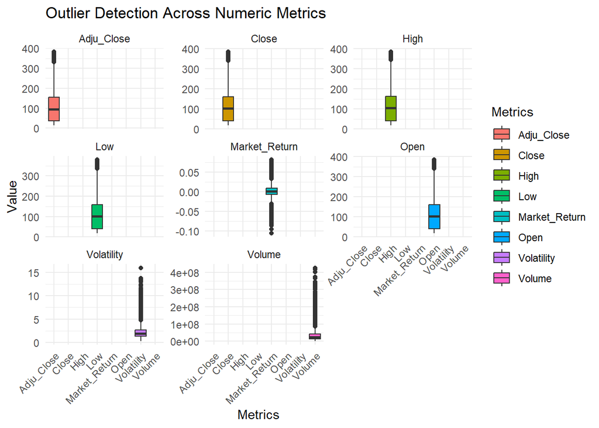

```r
# changing the format from a wide to long data
numeric_long_data <- numeric_var %>%
  pivot_longer(cols = c(Open, High, Low, Close, Adju_Close, Volume, Volatility,
                        Market_Return),
               names_to = "Metrics", values_to = "Value")
# Create the box plot for all numeric variables
ggplot(numeric_long_data, aes(x = Metrics, y = Value, fill=Metrics)) +
  geom_boxplot() +
  labs(title = "Outlier Detection Across Numeric Metrics", x = "Metrics", y = "Value") +
  facet_wrap(~Metrics, scales = "free_y") +
  theme_minimal() +
  theme(axis.text.x = element_text(angle = 45, hjust = 1))
```

#### **Outlier Observations**

- **Price Metrics (Adjusted Close, Close, High, Open)**: The presence of outliers in these metrics likely signifies days with exceptionally high stock prices. These could be attributed to specific market events or announcements affecting the companies’ stock values.
- **Market Return**: Outliers on both ends of the distribution suggest days with unusually high positive or negative returns, which could be critical in understanding market reactions to certain events.
- **Volume and Volatility**: A wide range of outliers in these metrics indicates days with abnormally high trading volume or price fluctuations. Such variations often occur in response to market news, earnings reports, or macroeconomic events, warranting further investigation.

#### **Rationale for Handling Outliers**

Upon detecting these outliers, I decided against removing or adjusting them in the dataset. My analysis indicated that these outliers represent true data points, not artifacts of data collection or preprocessing errors. Given the diverse scale of stock values and the nature of financial markets, such outliers reflect genuine market behaviors and critical events worth analyzing. Their presence enriches the dataset by offering insights into market dynamics and the impact of external factors on stock performance.

#### **Outcome**

Upon completion of the Data Preprocessing stage, the historical stock data has been successfully preprocessed to ensure consistency, accuracy, and suitability for analysis

## Methodolgy

The methodology adopted in this project involved a series of analytically steps I designed to explore the data across technology and financial sectors. Key techniques included descriptive statistics to grasp the data structure, distribution analysis for numerical variables, sector comparison using summary statistics, correlation analysis to identify relationships, seasonal trend evaluation, and time series analysis to observe over-time changes.

#### **Packages Used in this stage**

- `library(skimr)` used for understand my dataset
- `library(dplyr)` used for data manipulation
- `library(ggplot2)` used for visualization
- `library(tidyr)` used for data manipulation
- `library(e1071)` used for skewness and kurtosis calculations.
- `library(stats)` used for correlation analysis

#### **Understanding the Data**

I began my exploratory data analysis by thoroughly understanding the dataset. Initial examinations included assessing the data’s structure, datatypes, basic descriptive statistics, and ensuring no missing values were present. This groundwork was crucial for setting the stage for more detailed analyses.

Result from the `skim_without_charts` function shows my data has a total of 10,064 rows, 17 column as well as frequency of each data type of the columns (variables). It also dives deeper to analyse each variable type which included mostly **character**, **date**, **factor** and **numeric**.

```r
skim_without_charts(stock_market_data) #  a summary of Features and makeup of the dataset
```

Data summary

| Name | stock_market_data |
| --- | --- |
| Number of rows | 10064 |
| Number of columns | 17 |
| _______________________ |  |
| Column type frequency: |  |
| character | 5 |
| Date | 1 |
| factor | 3 |
| numeric | 8 |
| ________________________ |  |
| Group variables | None |

**Variable type: character**

| skim_variable | n_missing | complete_rate | min | max | empty | n_unique | whitespace |
| --- | --- | --- | --- | --- | --- | --- | --- |
| Symbol | 0 | 1 | 3 | 4 | 0 | 8 | 0 |
| Sector | 0 | 1 | 10 | 10 | 0 | 2 | 0 |
| Company | 0 | 1 | 6 | 27 | 0 | 8 | 0 |
| Year | 0 | 1 | 4 | 4 | 0 | 5 | 0 |
| Day | 0 | 1 | 2 | 2 | 0 | 31 | 0 |

**Variable type: Date**

| skim_variable | n_missing | complete_rate | min | max | median | n_unique |
| --- | --- | --- | --- | --- | --- | --- |
| Date | 0 | 1 | 2019-01-02 | 2023-12-29 | 2021-06-30 | 1258 |

**Variable type: factor**

| skim_variable | n_missing | complete_rate | ordered | n_unique | top_counts |
| --- | --- | --- | --- | --- | --- |
| Month | 0 | 1 | TRUE | 12 | Mar: 896, Aug: 888, Oct: 872, Jun: 848 |
| Day_of_Week | 0 | 1 | TRUE | 5 | Tue: 2072, Wed: 2072, Thu: 2040, Fri: 2016 |
| Quarter | 0 | 1 | TRUE | 4 | Q3: 2552, Q4: 2544, Q2: 2504, Q1: 2464 |

**Variable type: numeric**

| skim_variable | n_missing | complete_rate | mean | sd | p0 | p25 | p50 | p75 | p100 |
| --- | --- | --- | --- | --- | --- | --- | --- | --- | --- |
| Open | 0 | 1 | 116.35 | 88.27 | 18.01 | 40.21 | 102.88 | 160.04 | 3.8376e+02 |
| High | 0 | 1 | 117.69 | 89.29 | 18.12 | 40.61 | 103.88 | 162.04 | 3.8433e+02 |
| Low | 0 | 1 | 115.05 | 87.25 | 17.95 | 39.77 | 101.65 | 158.02 | 3.7881e+02 |
| Close | 0 | 1 | 116.41 | 88.31 | 18.08 | 40.20 | 102.79 | 160.09 | 3.8270e+02 |
| Volume | 0 | 1 | 34954314.25 | 36481913.71 | 536500.00 | 13813000.00 | 24369450.00 | 43200500.00 | 4.2651e+08 |
| Adju_Close | 0 | 1 | 112.88 | 88.60 | 14.48 | 36.38 | 95.06 | 154.43 | 3.8177e+02 |
| Market_Return | 0 | 1 | 0.00 | 0.02 | -0.11 | -0.01 | 0.00 | 0.01 | 8.0000e-02 |
| Volatility | 0 | 1 | 2.21 | 1.34 | 0.27 | 1.33 | 1.89 | 2.70 | 1.5960e+01 |

The results from the `str` function further shows the datatype of of each variable

```r
str(stock_market_data) # To understand the characteristics of each variables
```

```
## 'data.frame':    10064 obs. of  17 variables:
##  $ Date         : Date, format: "2019-01-02" "2019-01-03" ...
##  $ Open         : num  38.7 36 36.1 37.2 37.4 ...
##  $ High         : num  39.7 36.4 37.1 37.2 38 ...
##  $ Low          : num  38.6 35.5 36 36.5 37.1 ...
##  $ Close        : num  39.5 35.5 37.1 37 37.7 ...
##  $ Volume       : num  1.48e+08 3.65e+08 2.34e+08 2.19e+08 1.64e+08 ...
##  $ Adju_Close   : num  37.8 34 35.5 35.4 36.1 ...
##  $ Symbol       : chr  "AAPL" "AAPL" "AAPL" "AAPL" ...
##  $ Sector       : chr  "Technology" "Technology" "Technology" "Technology" ...
##  $ Company      : chr  "Apple Inc." "Apple Inc." "Apple Inc." "Apple Inc." ...
##  $ Market_Return: num  0.01919 -0.01259 0.02516 -0.00521 0.00789 ...
##  $ Volatility   : num  2.93 2.62 3.2 1.98 2.19 ...
##  $ Year         : chr  "2019" "2019" "2019" "2019" ...
##  $ Month        : Ord.factor w/ 12 levels "January"<"February"<..: 1 1 1 1 1 1 1 1 1 1 ...
##  $ Day          : chr  "02" "03" "04" "07" ...
##  $ Day_of_Week  : Ord.factor w/ 5 levels "Monday"<"Tuesday"<..: 3 4 5 1 2 3 4 5 1 2 ...
##  $ Quarter      : Ord.factor w/ 4 levels "Q1"<"Q2"<"Q3"<..: 1 1 1 1 1 1 1 1 1 1 ...
```

`summary` function gives a basic descriptive statistics overview of the dataset to understand how each variable are distributed and how each variable scales.

```r
summary(stock_market_data) # Get a view brief view of the dataset
```

```
##       Date                 Open             High             Low
##  Min.   :2019-01-02   Min.   : 18.01   Min.   : 18.12   Min.   : 17.95
##  1st Qu.:2020-04-01   1st Qu.: 40.21   1st Qu.: 40.60   1st Qu.: 39.77
##  Median :2021-06-30   Median :102.88   Median :103.88   Median :101.65
##  Mean   :2021-06-30   Mean   :116.35   Mean   :117.69   Mean   :115.05
##  3rd Qu.:2022-09-29   3rd Qu.:160.04   3rd Qu.:162.04   3rd Qu.:158.02
##  Max.   :2023-12-29   Max.   :383.76   Max.   :384.33   Max.   :378.81
##
##      Close            Volume            Adju_Close        Symbol
##  Min.   : 18.08   Min.   :   536500   Min.   : 14.48   Length:10064
##  1st Qu.: 40.20   1st Qu.: 13813000   1st Qu.: 36.38   Class :character
##  Median :102.79   Median : 24369450   Median : 95.06   Mode  :character
##  Mean   :116.41   Mean   : 34954314   Mean   :112.88
##  3rd Qu.:160.09   3rd Qu.: 43200500   3rd Qu.:154.43
##  Max.   :382.70   Max.   :426510000   Max.   :381.77
##
##     Sector            Company          Market_Return          Volatility
##  Length:10064       Length:10064       Min.   :-0.1062532   Min.   : 0.2684
##  Class :character   Class :character   1st Qu.:-0.0073860   1st Qu.: 1.3333
##  Mode  :character   Mode  :character   Median : 0.0006342   Median : 1.8948
##                                        Mean   : 0.0003502   Mean   : 2.2112
##                                        3rd Qu.: 0.0085984   3rd Qu.: 2.7036
##                                        Max.   : 0.0815397   Max.   :15.9636
##
##      Year                Month          Day               Day_of_Week
##  Length:10064       March   : 896   Length:10064       Monday   :1864
##  Class :character   August  : 888   Class :character   Tuesday  :2072
##  Mode  :character   October : 872   Mode  :character   Wednesday:2072
##                     June    : 848                      Thursday :2040
##                     December: 848                      Friday   :2016
##                     May     : 840
##                     (Other) :4872
##  Quarter
##  Q1:2464
##  Q2:2504
##  Q3:2552
##  Q4:2544
##
##
##
```

the `glimpse` function gives a brief overview of the dataset including the observations

```r
glimpse(stock_market_data)
```

```
## Rows: 10,064
## Columns: 17
## $ Date          <date> 2019-01-02, 2019-01-03, 2019-01-04, 2019-01-07, 2019-01…
## $ Open          <dbl> 38.7225, 35.9950, 36.1325, 37.1750, 37.3900, 37.8225, 38…
## $ High          <dbl> 39.7125, 36.4300, 37.1375, 37.2075, 37.9550, 38.6325, 38…
## $ Low           <dbl> 38.5575, 35.5000, 35.9500, 36.4750, 37.1300, 37.4075, 37…
## $ Close         <dbl> 39.4800, 35.5475, 37.0650, 36.9825, 37.6875, 38.3275, 38…
## $ Volume        <dbl> 148158800, 365248800, 234428400, 219111200, 164101200, 1…
## $ Adju_Close    <dbl> 37.79379, 34.02925, 35.48192, 35.40295, 36.07784, 36.690…
## $ Symbol        <chr> "AAPL", "AAPL", "AAPL", "AAPL", "AAPL", "AAPL", "AAPL", …
## $ Sector        <chr> "Technology", "Technology", "Technology", "Technology", …
## $ Company       <chr> "Apple Inc.", "Apple Inc.", "Apple Inc.", "Apple Inc.", …
## $ Market_Return <dbl> 0.019186923, -0.012588742, 0.025158477, -0.005205194, 0.…
## $ Volatility    <dbl> 2.925539, 2.616219, 3.203831, 1.980672, 2.189057, 3.1961…
## $ Year          <chr> "2019", "2019", "2019", "2019", "2019", "2019", "2019", …
## $ Month         <ord> January, January, January, January, January, January, Ja…
## $ Day           <chr> "02", "03", "04", "07", "08", "09", "10", "11", "14", "1…
## $ Day_of_Week   <ord> Wednesday, Thursday, Friday, Monday, Tuesday, Wednesday,…
## $ Quarter       <ord> Q1, Q1, Q1, Q1, Q1, Q1, Q1, Q1, Q1, Q1, Q1, Q1, Q1, Q1, …
```

#### **Assessing Distribution with Skewness and Kurtosis**

To gauge the distribution of numeric variables, I utilized skewness and kurtosis calculations. These revealed right-skewed distributions for price-related metrics and volume, pointing to the presence of outliers which has been explained earlier and the occasional days of high market activity.Used a histogram & density combined plot to show this distribution

```r
#Calculate skewness to understand distribution of numeric variables
apply(numeric_var[, sapply(numeric_var, is.numeric)], 2, skewness)
```

```
##          Open          High           Low         Close    Adju_Close
##     0.9817731     0.9787022     0.9831110     0.9810553     0.9958967
##        Volume    Volatility Market_Return
##     3.0794131     2.3733577    -0.1521943
```

Skewness is used to measure the degree to which the distribution of a variable is or is not a normal distribution.When the skewness results ranges from -0.5 to + 0.5 it is a normal distribution, when the result is a negative value it means the variable is directed towards the left with more values on the right side of the distribution and when positive means the variable is directed towards the right with more values on the left. When the values of a skewness result is greater than -1 or +1 it indicates extreme skewness and possibility of outilers.

```r
#Calculate kurtosis to understand the shape of the distribution of numeric variables
apply(numeric_var[, sapply(numeric_var, is.numeric)], 2, kurtosis)
```

```
##          Open          High           Low         Close    Adju_Close
##     0.1389458     0.1262213     0.1474468     0.1378974     0.1696788
##        Volume    Volatility Market_Return
##    15.7802851    10.2376976     3.0234133
```

Kurtosis is used to know shape of distribution of variables. A kurtosis value of 3 means that variable is a normal distribution, when less 3 or greater than 3 then it suggest presents of extreme values that is causing the distribution to deviate from a normal distribution

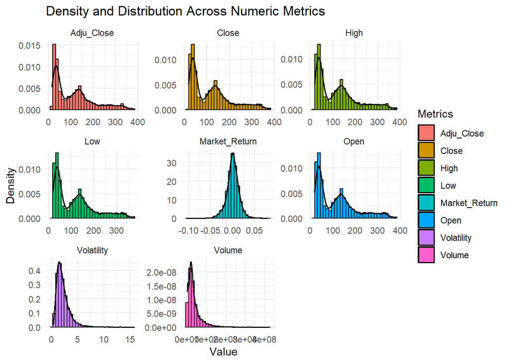

```r
# Plotting Histogram and Density chart for distribution of numeric variables
ggplot(numeric_long_data, aes(x = Value, fill=Metrics)) +
  geom_histogram(aes(y = ..density..), bins = 30, color = "black") +
  geom_density(alpha = 0.2, size=0.7) +
  facet_wrap(~ Metrics, scales = "free") +
  labs(title = "Density and Distribution Across Numeric Metrics", x = "Value", y = "Density") +
  theme_minimal()
```

**From the histograms**:

- The distributions of Adjusted Close, Close, High, Low, and Open are skewed right, meaning that there are a number of very high values (outliers) pulling the mean upwards.
- Market Return appears to have a distribution that is centered around zero with tails on both ends, suggesting days with both significant gains and losses.
- Volume and Volatility both show a right-skewed distribution, indicating occasional days with very high trading volume or large price movements, which are less frequent but have a significant impact on the distribution.

#### **Sector-Based Statistical Summaries**

My analysis extended to comparing key metrics between the Technology and Financial sectors through bar charts.

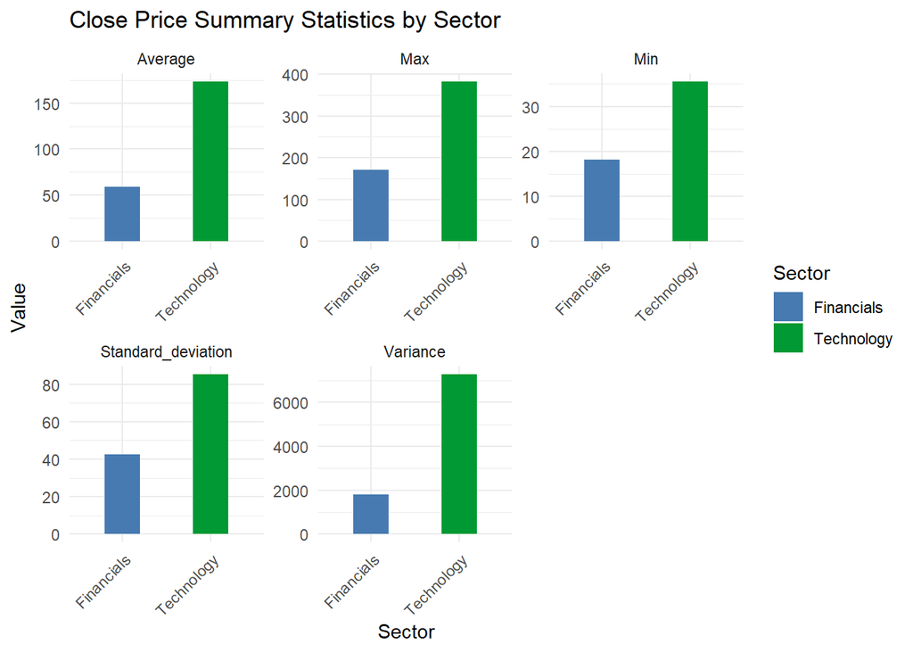

```r
# Summary of some descriptive Statistics for key metrics based on sector
# 1 for Close Price
stock_market_data %>% group_by(Sector) %>%
  summarise(Min  = min(Close),
            Max = max(Close),
            Average = mean(Close),
            Variance = var(Close),
            Standard_deviation = sd(Close)
            ) %>%
  pivot_longer(cols = -Sector,
               names_to = "Statistic",
               values_to = "Value") %>%
  ggplot(aes(x = Sector, y = Value, fill = Sector)) +
  geom_col(position = "dodge", width = 0.4) +
  scale_fill_manual(values =
                      c("Financials" = "#467ab0",
                        "Technology" = "#009933")) +
  facet_wrap(~Statistic, scales = "free") +
  theme_minimal() +
  labs(title = "Close Price Summary Statistics by Sector",
       x = "Sector",
       y = "Value") +
  theme(axis.text.x = element_text(angle = 45, hjust = 1))
```

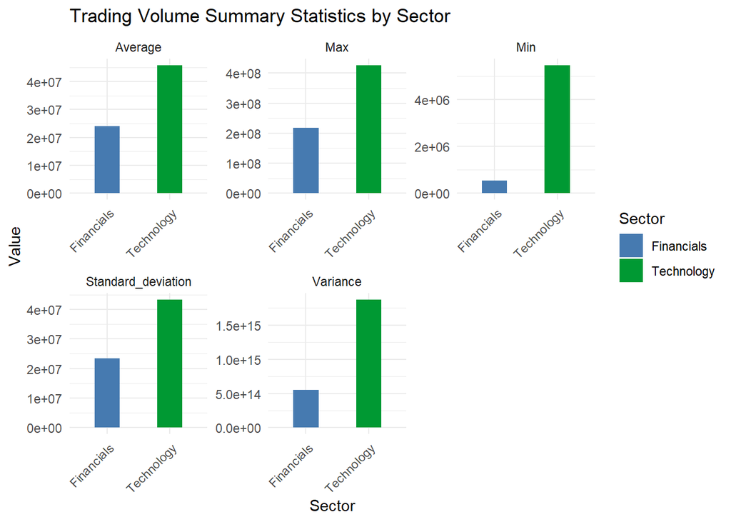

```r
# 2 Volume
stock_market_data %>% group_by(Sector) %>%
  summarise(Min  = min(Volume),
            Max = max(Volume),
            Average = mean(Volume),
            Variance = var(Volume),
            Standard_deviation = sd(Volume)
            ) %>%
  pivot_longer(cols = -Sector,
               names_to = "Statistic",
               values_to = "Value") %>%
  ggplot(aes(x = Sector, y = Value, fill = Sector)) +
  geom_col(position = "dodge", width = 0.4) +
  scale_fill_manual(values =
                      c("Financials" = "#467ab0",
                        "Technology" = "#009933")) +
  facet_wrap(~Statistic, scales = "free") +
  theme_minimal() +
  labs(title = "Trading Volume Summary Statistics by Sector",
       x = "Sector",
       y = "Value") +
  theme(axis.text.x = element_text(angle = 45, hjust = 1))
```

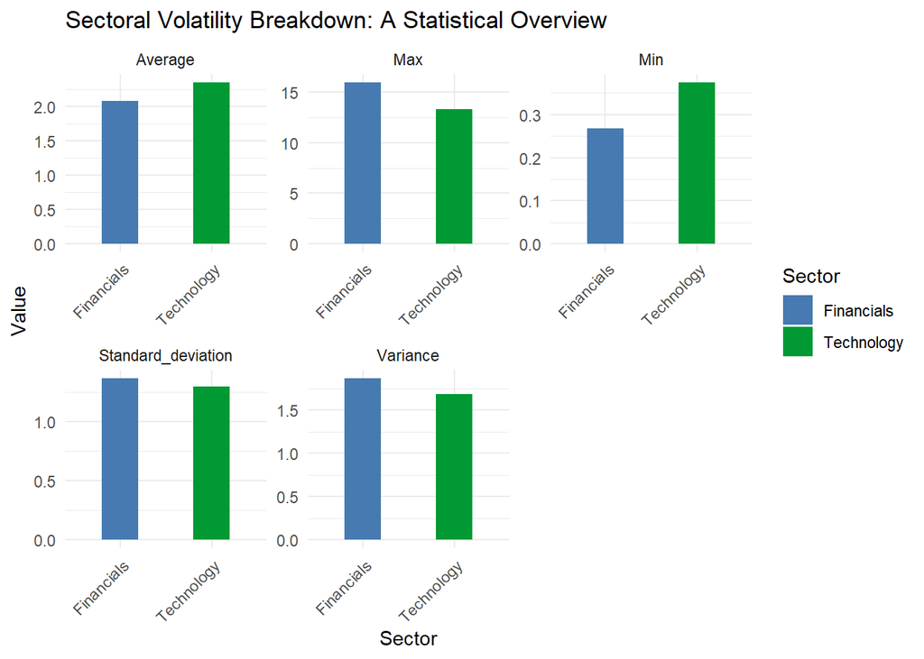

```r
# 3 for Volatility
stock_market_data %>% group_by(Sector) %>%
  summarise(Min  = min(Volatility),
            Max = max(Volatility),
            Average = mean(Volatility),
            Variance = var(Volatility),
            Standard_deviation = sd(Volatility)
            ) %>%
  pivot_longer(cols = -Sector,
               names_to = "Statistic",
               values_to = "Value") %>%
  ggplot(aes(x = Sector, y = Value, fill = Sector)) +
  geom_col(position = "dodge", width = 0.4) +
  scale_fill_manual(values =
                      c("Financials" = "#467ab0",
                        "Technology" = "#009933")) +
  facet_wrap(~Statistic, scales = "free") +
  theme_minimal() +
  labs(title = "Sectoral Volatility Breakdown: A Statistical Overview",
       x = "Sector",
       y = "Value") +
  theme(axis.text.x = element_text(angle = 45, hjust = 1))
```

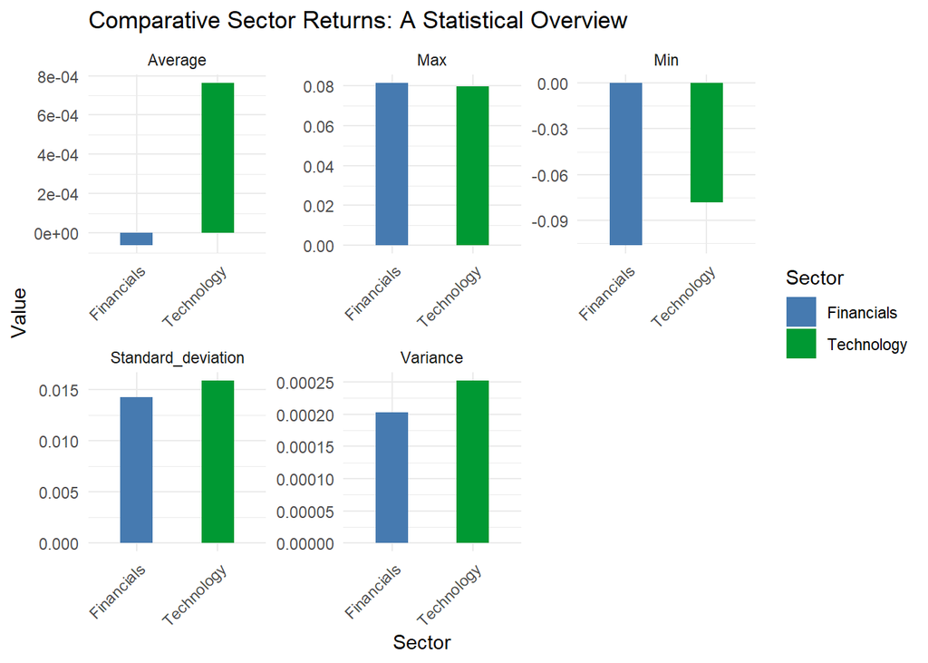

```r
# 4 for Market_Return
stock_market_data %>% group_by(Sector) %>%
  summarise(Min  = min(Market_Return),
            Max = max(Market_Return),
            Average = mean(Market_Return),
            Variance = var(Market_Return),
            Standard_deviation = sd(Market_Return)
            ) %>%
  pivot_longer(cols = -Sector,
               names_to = "Statistic",
               values_to = "Value") %>%
  ggplot(aes(x = Sector, y = Value, fill = Sector)) +
  geom_col(position = "dodge", width = 0.4) +
  scale_fill_manual(values =
                      c("Financials" = "#467ab0",
                        "Technology" = "#009933")) +
  facet_wrap(~Statistic, scales = "free") +
  theme_minimal() +
  labs(title = "Comparative Sector Returns: A Statistical Overview",
       x = "Sector",
       y = "Value") +
  theme(axis.text.x = element_text(angle = 45, hjust = 1))
```

**Close Price Summary Statistics by Sector**

- Technology stocks have a much higher average, maximum, and minimum close price than Financials.
- The standard deviation and variance are also significantly higher for Technology, indicating a wider dispersion of close prices.

**Trading Volume Summary Statistics by Sector**

- The average and maximum trading volumes are higher for Technology stocks compared to Financials.
- The standard deviation and variance for trading volume are much larger in the Technology sector, implying more variability in the number of shares traded.

**Volatility Summary Statistics by Sector**

- The average volatility is slightly higher for Technology than for Financials. However, the maximum volatility observed is substantially higher in the Financials sector.
- The Financials sector exhibits higher dispersion in volatility, as shown by the greater standard deviation and variance.

**Market Return Summary Statistics by Sector**

- The average return is higher for Technology stocks than for Financials, but this comes with greater risk as indicated by a higher standard deviation and variance.
- The maximum return observed is similar for both sectors, yet Technology shows a higher minimum return compared to Financials.

#### **Correlation Analysis**

By calculating correlation coefficients and visualizing these relationships through scatter plots, I identified significant correlations, such as the strong link between open and close prices. This step was pivotal in understanding the interconnections of market variables.

```r
# Calculate Correlation Coefficient to understand how variables relate with each other
cor(numeric_var)
```

```
##                       Open         High          Low       Close  Adju_Close
## Open           1.000000000  0.999857223  0.999847605  0.99967878  0.99881508
## High           0.999857223  1.000000000  0.999803670  0.99984437  0.99905034
## Low            0.999847605  0.999803670  1.000000000  0.99985358  0.99893737
## Close          0.999678777  0.999844371  0.999853581  1.00000000  0.99914330
## Adju_Close     0.998815079  0.999050338  0.998937371  0.99914330  1.00000000
## Volume        -0.067450155 -0.065142831 -0.070019307 -0.06763402 -0.05656380
## Volatility     0.056667000  0.064027857  0.048442420  0.05567642  0.06309604
## Market_Return -0.003688835  0.006054763  0.006706176  0.01674214  0.01695812
##                    Volume  Volatility Market_Return
## Open          -0.06745015  0.05666700  -0.003688835
## High          -0.06514283  0.06402786   0.006054763
## Low           -0.07001931  0.04844242   0.006706176
## Close         -0.06763402  0.05567642   0.016742135
## Adju_Close    -0.05656380  0.06309604   0.016958119
## Volume         1.00000000  0.38497347  -0.009349220
## Volatility     0.38497347  1.00000000  -0.049658278
## Market_Return -0.00934922 -0.04965828   1.000000000
```

Correlation is a measure that is done to understand the strength of linear relationship between two variables. with the values ranging from

**Strong correlation** Positive: +0.7 to +1.0 Negative: -0.7 to -1.0

**Moderate correlation** Positive: +0.3 to +0.7 Negative: -0.3 to -0.7

**Weak correlation** Positive: +0.1 to +0.3 Negative: -0.1 to -0.3

**No or negligible correlation** Around 0, typically in the range of -0.1 to +0.1

**Correlation Results Among variables**

- **Open vs Close**: The correlation is extremely high at 0.9997, indicating that the opening and closing prices for the day are almost perfectly aligned.
- **High vs Low**: Similarly, there’s an extremely high correlation of 0.9998 between the highest and lowest prices of the day.
- **Close vs Market Return**: The correlation is 0.0167, suggesting a very weak positive relationship between the closing price and market return for the day.
- **Volume vs Market Return**: With a correlation of -0.0093, there’s virtually no relationship between trading volume and market return.
- **Volume vs Volatility**: The correlation is 0.385, indicating a moderate positive relationship between trading volume and volatility.
- **High vs Volatility**: The correlation of 0.064 suggests a very weak positive relationship between the highest price of the day and volatility.
- **Market Return vs Volatility**: The correlation is -0.0497, indicating a very weak negative relationship between market return and volatility.

**Scatter Plot visuals showing relationship among variables**

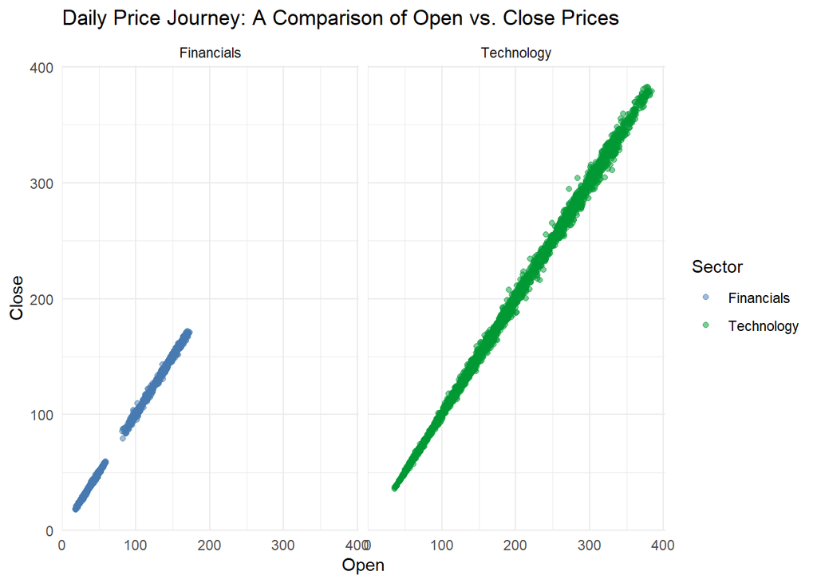

```r
# Plotting scatter plot to show some key correlation results
# 1 Open Vs Close
ggplot(data = stock_market_data, aes(x=Open, y=Close, color= Sector)) +
  geom_point(alpha=0.5) +
  theme_minimal() +
  scale_color_manual(values =
                      c("Financials" = "#467ab0",
                        "Technology" = "#009933")) +
   labs(title = "Daily Price Journey: A Comparison of Open vs. Close Prices",
        x="Open",
        y="Close") +
  facet_wrap(~ Sector)
```

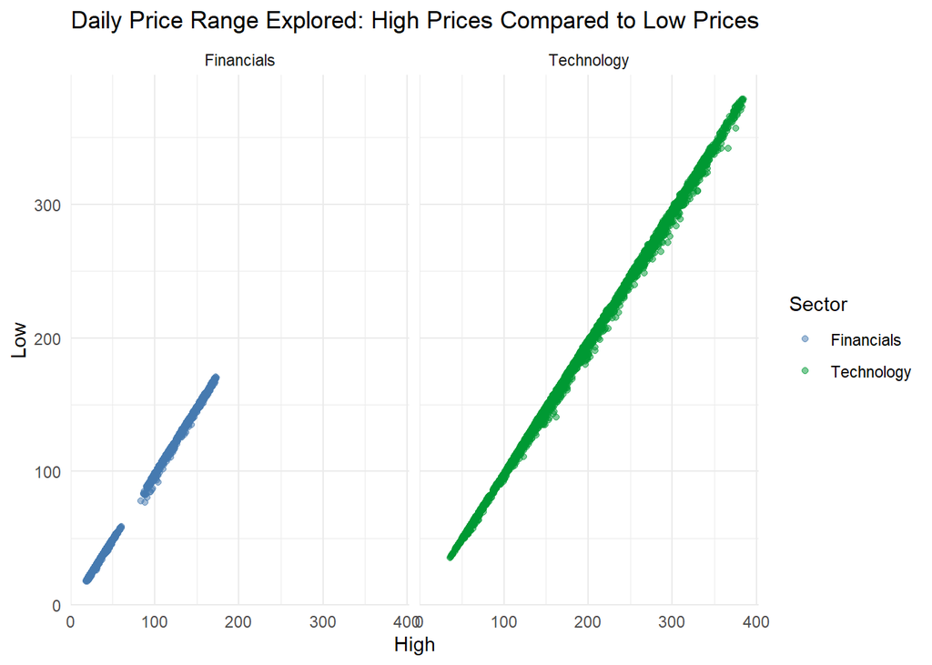

```r
# 2 High Vs Low
ggplot(data = stock_market_data, aes(x=High, y=Low, color= Sector)) +
  geom_point(alpha=0.5) +
  theme_minimal() +
  scale_color_manual(values =
                      c("Financials" = "#467ab0",
                        "Technology" = "#009933")) +
   labs(title = "Daily Price Range Explored: High Prices Compared to Low Prices",
        x="High",
        y="Low") +
  facet_wrap(~ Sector)
```

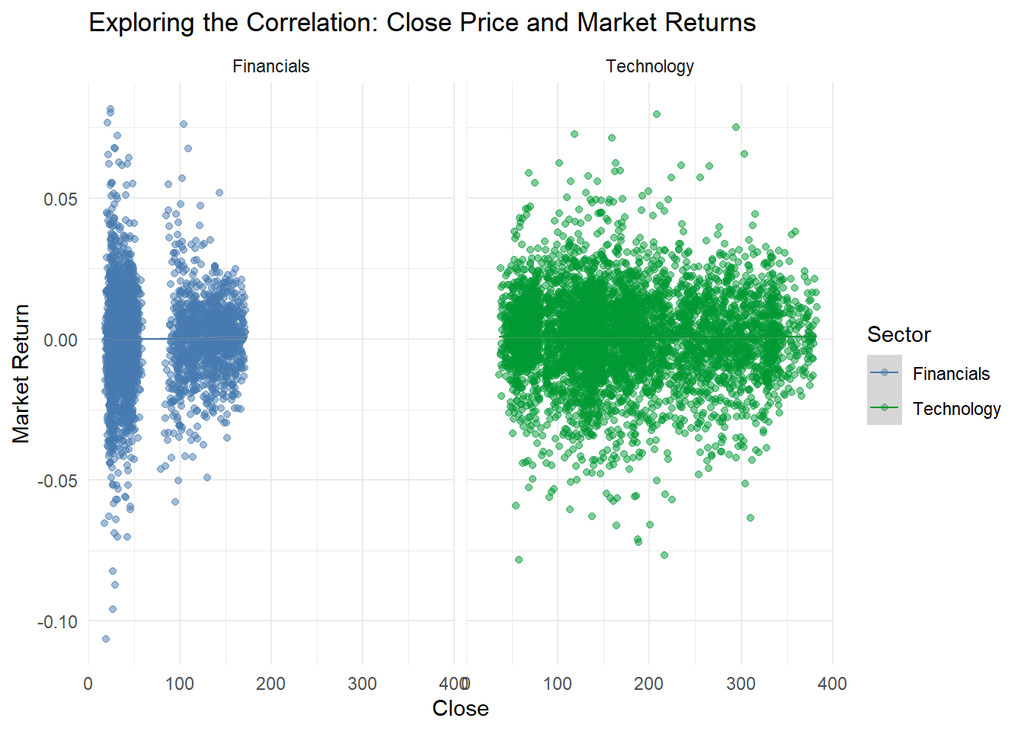

```r
# 3 Close Vs Market Return
ggplot(data = stock_market_data, aes(x=Close, y=Market_Return, color= Sector)) +
  geom_point(alpha=0.5) +
  geom_smooth(size=0.5) +
  theme_minimal() +
  scale_color_manual(values =
                      c("Financials" = "#467ab0",
                        "Technology" = "#009933")) +
   labs(title = "Exploring the Correlation: Close Price and Market Returns",
        x="Close",
        y="Market Return") +
  facet_wrap(~ Sector)
```

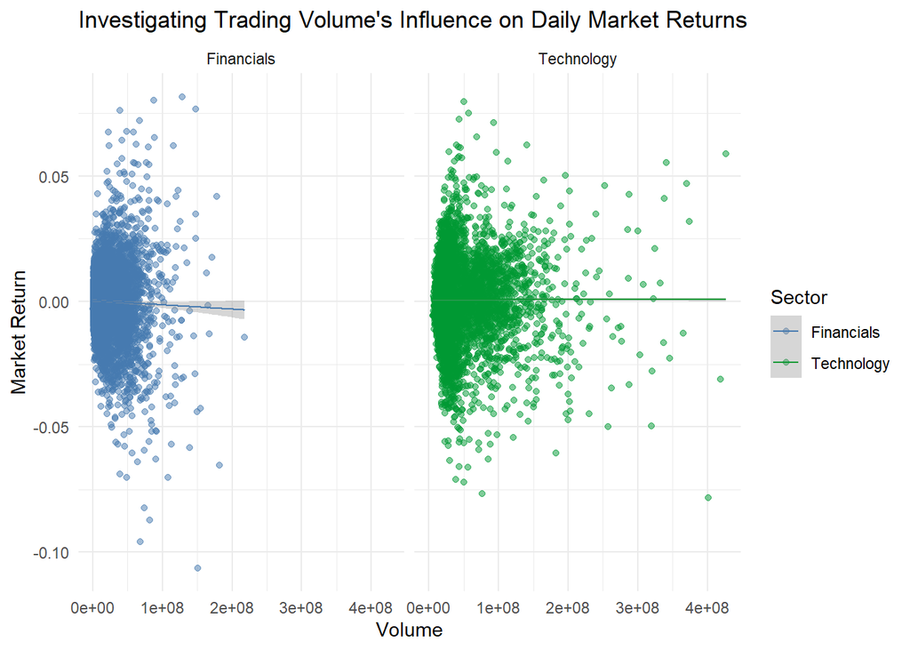

```r
# 4 Volume Vs Market Return
ggplot(data = stock_market_data, aes(x=Volume, y=Market_Return, color= Sector)) +
  geom_point(alpha=0.5) +
  geom_smooth(size=0.5) +
  theme_minimal() +
  scale_color_manual(values =
                      c("Financials" = "#467ab0",
                        "Technology" = "#009933")) +
   labs(title = "Investigating Trading Volume's Influence on Daily Market Returns",
        x="Volume",
        y="Market Return") +
  facet_wrap(~ Sector)
```

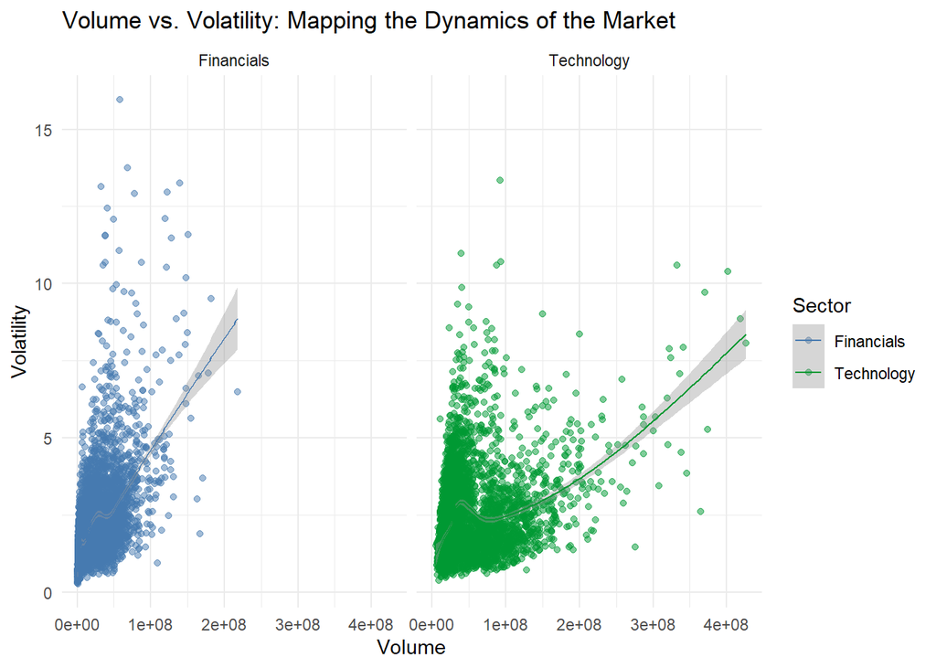

```r
# 5 Volume Vs Volatility
ggplot(data = stock_market_data, aes(x=Volume, y=Volatility, color= Sector)) +
  geom_point(alpha=0.5) +
  geom_smooth(size=0.5) +
  theme_minimal() +
  scale_color_manual(values =
                      c("Financials" = "#467ab0",
                        "Technology" = "#009933")) +
   labs(title = "Volume vs. Volatility: Mapping the Dynamics of the Market",
        x="Volume",
        y="Volatility") +
  facet_wrap(~ Sector)
```

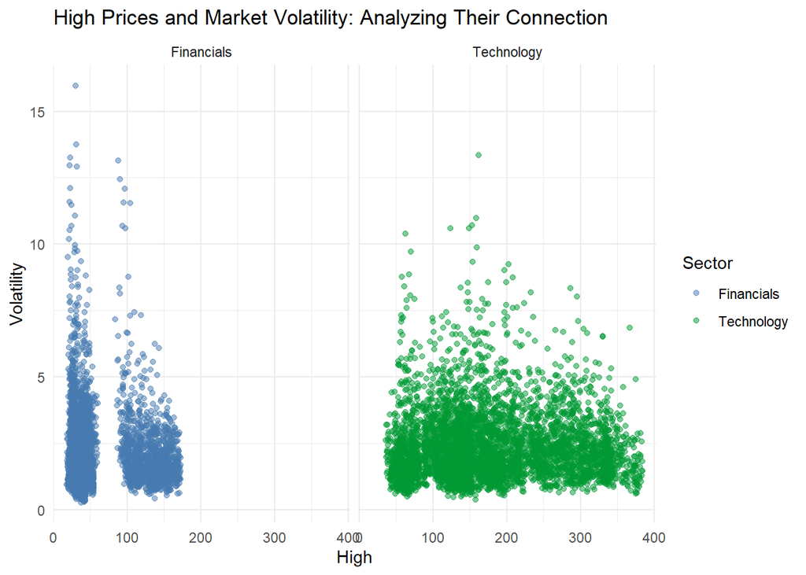

```r
# 6 High Vs Volatility
ggplot(data = stock_market_data, aes(x=High, y=Volatility, color= Sector)) +
  geom_point(alpha=0.5) +
  theme_minimal() +
  scale_color_manual(values =
                      c("Financials" = "#467ab0",
                        "Technology" = "#009933")) +
   labs(title = "High Prices and Market Volatility: Analyzing Their Connection",
        x="High",
        y="Volatility") +
  facet_wrap(~ Sector)
```

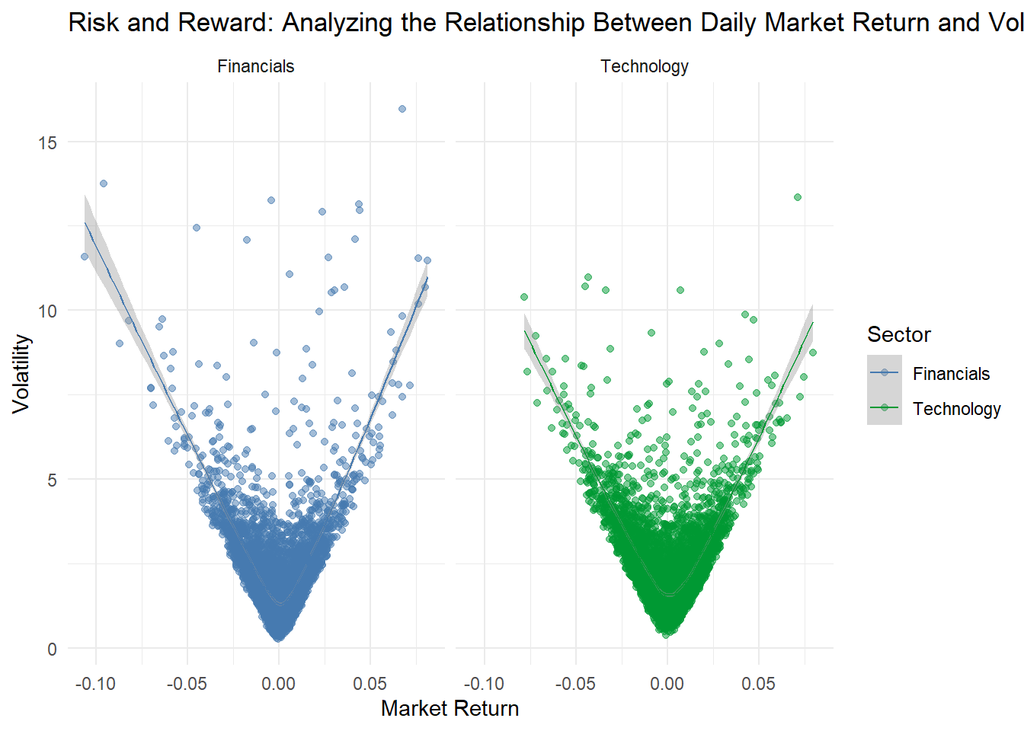

```r
# 7 Market Return Vs Volatility
ggplot(data = stock_market_data, aes(x=Market_Return, y=Volatility, color= Sector)) +
  geom_point(alpha=0.5) +
  geom_smooth(size=0.5) +
  theme_minimal() +
  scale_color_manual(values =
                      c("Financials" = "#467ab0",
                        "Technology" = "#009933")) +
   labs(title = "Risk and Reward: Analyzing the Relationship Between Daily Market Return and Volatility",
        x="Market Return",
        y="Volatility") +
  facet_wrap(~ Sector)
```

**Correlation and Visuals when Year is taken as an independent variable against another variable to identify trend**

```r
#correlation  btw year taking year as an independent variable and other variables to understand trend
as.numeric(stock_market_data$Year) %>%
  cor(stock_market_data[sapply(stock_market_data, is.numeric)])
```

```
##           Open      High       Low     Close    Volume Adju_Close Market_Return
## [1,] 0.2218057 0.2223865 0.2216877 0.2219661 -0.108211  0.2349949 -0.0002559605
##      Volatility
## [1,] 0.06294154
```

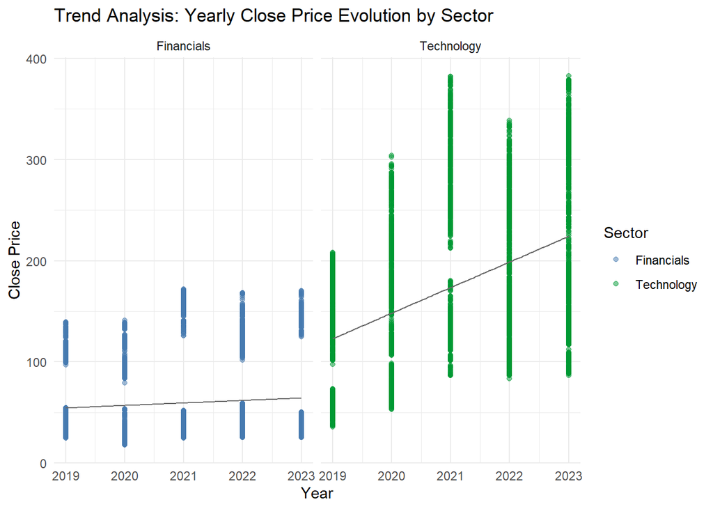

```r
# 1. Year vs Close Price
ggplot(stock_market_data, aes(x = as.numeric(Year), y = Close, color = Sector)) +
  geom_point(alpha = 0.5) +  # Scatter plot
  geom_smooth(method = "lm", se = FALSE, color = "#696969", size=0.5) +
  scale_color_manual(values =
                       c("Financials" = "#467ab0",
                         "Technology" = "#009933")) +
  facet_wrap(~Sector) +  # Separate plots for each sector
  labs(title = "Trend Analysis: Yearly Close Price Evolution by Sector",
       x = "Year",
       y = "Close Price") +
  theme_minimal()
```

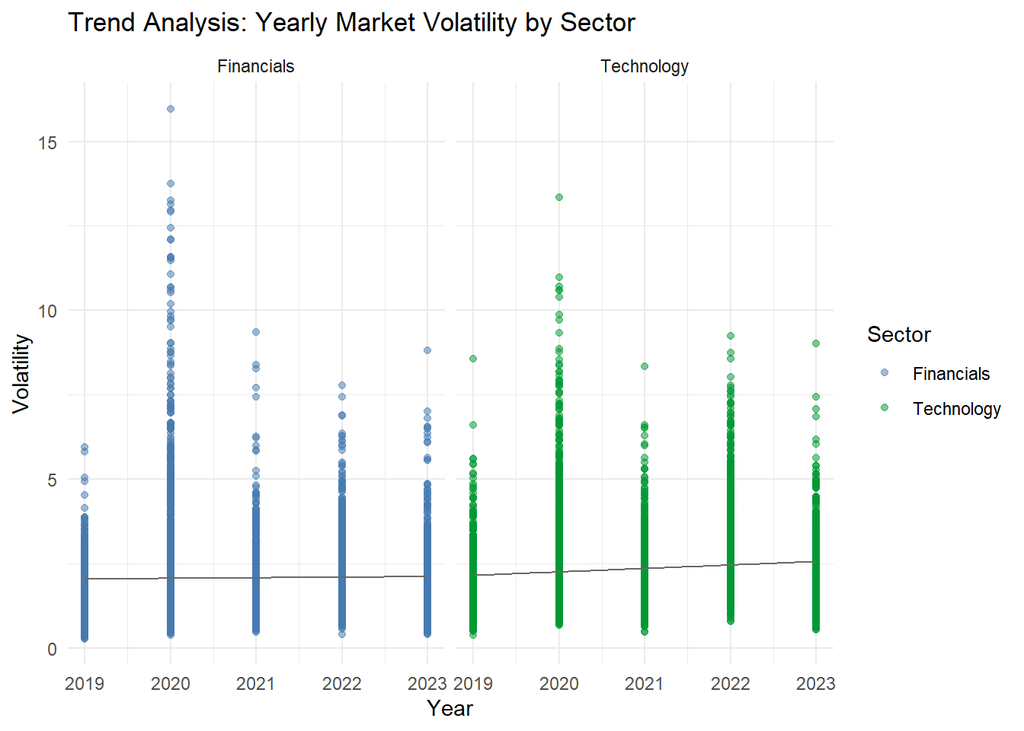

```r
# 2. Year vs Volatility
ggplot(stock_market_data, aes(x = as.numeric(Year), y = Volatility, color = Sector)) +
  geom_point(alpha = 0.5) +  # Scatter plot
  geom_smooth(method = "lm", se = FALSE, color = "#696969", size=0.5) +
  scale_color_manual(values =
                       c("Financials" = "#467ab0",
                         "Technology" = "#009933")) +
  facet_wrap(~Sector) +  # Separate plots for each sector
  labs(title = "Trend Analysis: Yearly Market Volatility by Sector",
       x = "Year",
       y = "Volatility") +
  theme_minimal()
```